# Technical Report: Determinants of PH in Beverage Process

Alexander Ng, Philip Tanofsky

Due 12/13/2021

# Introduction

# Importing Data

```r
sdata_train_pp = read_csv("sdata_train_pp.csv",
                          col_types = cols( .default = "?", id = "i" , BrandCode = "f")) %>%
  as_tibble() %>% remove_rownames()

sdata_test_pp  = read_csv("sdata_test_pp.csv", col_types = cols( .default = "?", id = "i" , BrandCode = "f")) %>%
  as_tibble() %>% remove_rownames()

sdata_trainX_pp  = sdata_train_pp %>% select( -PH, -id )
sdata_testX_pp   = sdata_test_pp %>% select(-PH , -id)
```

```r
tuningFull = FALSE   # Set to TRUE if running the lengthy tuning process for all models
```

# Gradient Boosted Trees

We consider the same dataset and variable importance problem using gradient boosted trees. The `gbm` library and variable importance measures are run within caret training procedure.

```r
set.seed( 1027)

gbmControlFull <- trainControl(method = "repeatedcv",
                           number = 10,  # for debug mode, set this to a low number (1)
                           repeats = 10 ,
                           selectionFunction = "best",
                           verboseIter = FALSE)

gbmControlLight <- trainControl(method = "repeatedcv",
                           number = 5,  # for debug mode, set this to a low number (1)
                           repeats = 1 ,
                           selectionFunction = "best",
                           verboseIter = FALSE)

if(tuningFull == TRUE)
{
   gbmControl = gbmControlFull
   gbmTune = expand.grid( n.trees = c( 1000, 2000),
                                                  shrinkage = c( 0.02, 0.05,  0.1 , 0.15 ) ,
                                                  interaction.depth = c(  3, 7) ,
                                                  n.minobsinnode = 4
                                                  )
} else  {
   gbmControl = gbmControlLight
   gbmTune =  expand.grid( n.trees = c( 2000),
                                                  shrinkage = c( 0.02, 0.05 , 0.1 ) ,
                                                  interaction.depth = c(  3, 7) ,
                                                  n.minobsinnode = 4
                                                  )
}

(gbmTune = caret::train( x = sdata_trainX_pp,
                          y = sdata_train_pp$PH ,
                          method = "gbm",
                          tuneGrid =  gbmTune ,
                          verbose = FALSE,
                          metric = "RMSE" ,
                          trControl = gbmControl ) )
```

```
## Stochastic Gradient Boosting
##
## 2055 samples
##   32 predictor
##
## No pre-processing
## Resampling: Cross-Validated (5 fold, repeated 1 times)
## Summary of sample sizes: 1643, 1643, 1645, 1645, 1644
## Resampling results across tuning parameters:
##
##   shrinkage  interaction.depth  RMSE       Rsquared   MAE
##   0.02       3                  0.1356404  0.4167016  0.1049312
##   0.02       7                  0.1302142  0.4662114  0.1000884
##   0.05       3                  0.1346098  0.4349343  0.1033941
##   0.05       7                  0.1306841  0.4636265  0.1001983
##   0.10       3                  0.1365008  0.4250420  0.1046381
##   0.10       7                  0.1338216  0.4459236  0.1027271
##
## Tuning parameter 'n.trees' was held constant at a value of 2000
##
## Tuning parameter 'n.minobsinnode' was held constant at a value of 4
## RMSE was used to select the optimal model using the smallest value.
## The final values used for the model were n.trees = 2000, interaction.depth =
##  7, shrinkage = 0.02 and n.minobsinnode = 4.
```

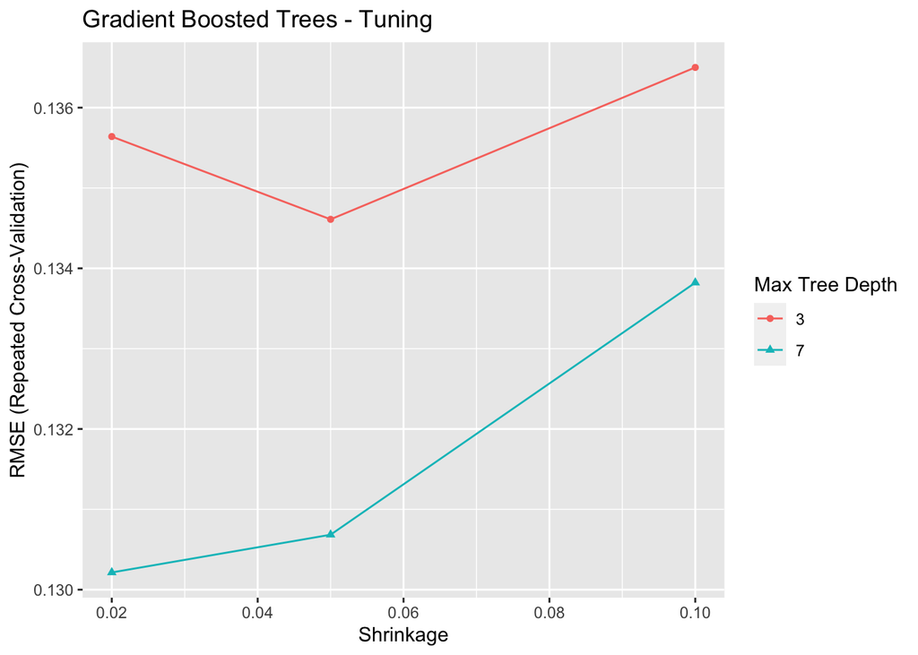

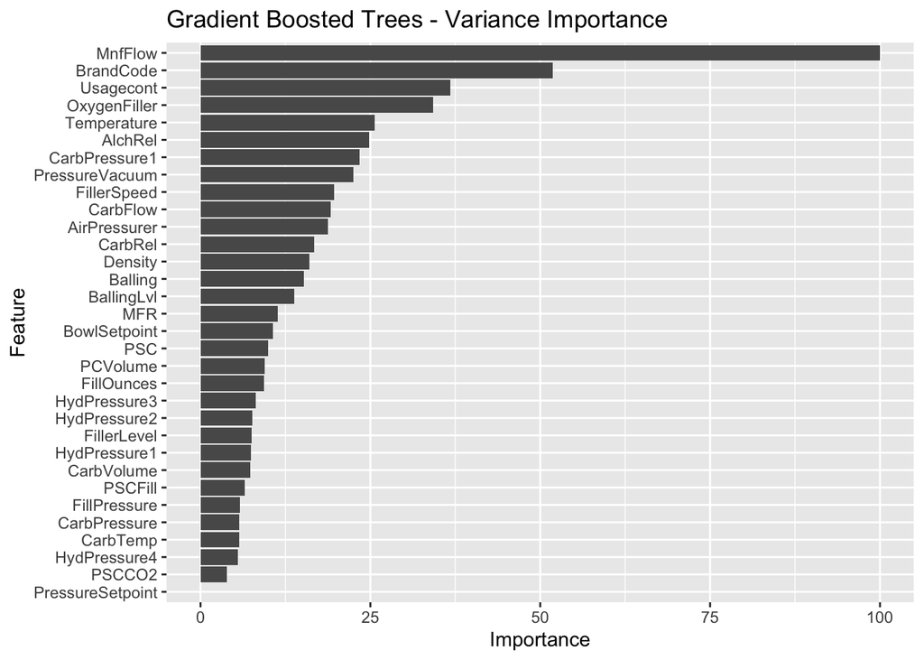

# Cubist Model

Now we train a Cubist tree using the `best` selectionFunction on RMSE.

```r
set.seed( 1027)

cubistControlFull <- trainControl(method = "cv" ,  selectionFunction = "best")
tuneGridFull  <- expand.grid( committees = c( 10, 50, 100 ) ,
                              neighbors = c( 0, 1, 5, 9 )
                                                  )

cubistControlLight <- trainControl(method = "cv" ,  selectionFunction = "best")
tuneGridLight <- expand.grid( committees = c( 10, 20 ) ,
                              neighbors = c( 0, 5 )  )

if(tuningFull == TRUE)
{
   cubistControl = cubistControlFull
   cubistGrid = tuneGridFull
} else  {
   cubistControl = cubistControlLight
   cubistGrid = tuneGridLight
}



(cubistTune = caret::train( x = sdata_trainX_pp,
                          y = sdata_train_pp$PH ,
                          method = "cubist",
                          tuneGrid = cubistGrid ,
                          verbose = FALSE,
                          metric = "RMSE" ,
                          trControl = cubistControl ) )
```

```
## Cubist
##
## 2055 samples
##   32 predictor
##
## No pre-processing
## Resampling: Cross-Validated (10 fold)
## Summary of sample sizes: 1850, 1849, 1849, 1851, 1850, 1849, ...
## Resampling results across tuning parameters:
##
##   committees  neighbors  RMSE        Rsquared   MAE
##   10          0          0.10326126  0.6469501  0.07521436
##   10          5          0.09661241  0.6865169  0.06923965
##   20          0          0.10227374  0.6548914  0.07400171
##   20          5          0.09566196  0.6929795  0.06829498
##
## RMSE was used to select the optimal model using the smallest value.
## The final values used for the model were committees = 20 and neighbors = 5.
```

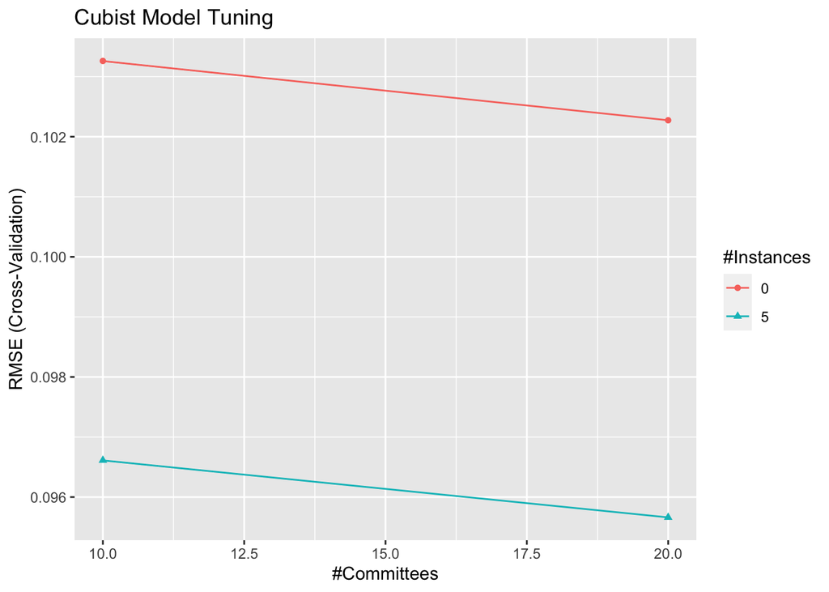

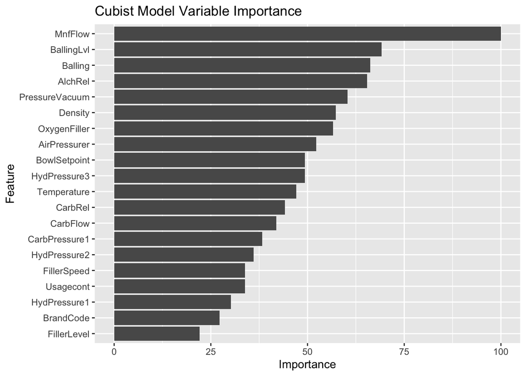

```
##
## Call:
## cubist.default(x = x, y = y, committees = param$committees, verbose = FALSE)
##
## Number of samples: 2055
## Number of predictors: 32
##
## Number of committees: 20
## Number of rules per committee: 20, 27, 19, 24, 20, 25, 27, 23, 25, 14, 23, 20, 32, 28, 18, 30, 21, 23, 20, 20
```

Cubist Predictor Usage

| Conditions | Model | Variable |
| --- | --- | --- |
| 80 | 60 | MnfFlow |
| 25 | 73 | BallingLvl |
| 15 | 79 | Balling |
| 19 | 74 | AlchRel |
| 27 | 59 | PressureVacuum |
| 16 | 66 | Density |
| 17 | 64 | OxygenFiller |
| 12 | 63 | AirPressurer |
| 19 | 52 | BowlSetpoint |
| 8 | 63 | HydPressure3 |
| 6 | 62 | Temperature |
| 7 | 57 | CarbRel |
| 17 | 44 | CarbFlow |
| 3 | 53 | CarbPressure1 |
| 2 | 51 | HydPressure2 |
| 19 | 31 | FillerSpeed |
| 13 | 37 | Usagecont |
| 7 | 38 | HydPressure1 |
| 41 | 0 | BrandCode |
| 2 | 32 | FillerLevel |
| 3 | 22 | PCVolume |
| 0 | 24 | CarbPressure |
| 0 | 22 | PressureSetpoint |
| 3 | 18 | CarbVolume |
| 0 | 18 | PSCFill |
| 0 | 18 | FillPressure |
| 0 | 17 | CarbTemp |
| 0 | 16 | HydPressure4 |
| 0 | 6 | MFR |
| 0 | 4 | FillOunces |
| 0 | 4 | PSC |
| 0 | 4 | PSCCO2 |

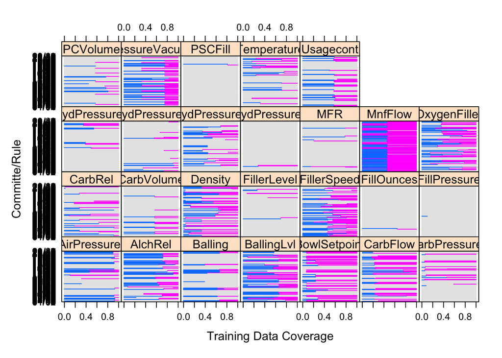

The `dotplot` allows us to allows us to see the distribution of the coefficient parameters for each linear model associated with a committee/rule.  
When a predictor has more dots, it is used in more models which suggests it is influential. The sign of the coefficient tells us whether the marginal effect of the predictor on the response `PH`. However, since Cubist uses many models, the concept of the `sign` of a predictor coefficient is unclear.

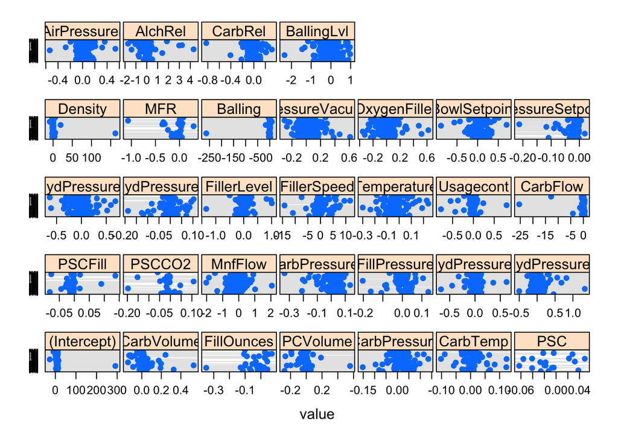

The boxplot below which I devised constructs a distribution of coefficients for each predictor. We interpret the sign of the predictor $X$ marginal effect to be the sign of the median of the distribution of coefficients pf $X$ over those models which include $X$. The predictors have been sorted by their median.

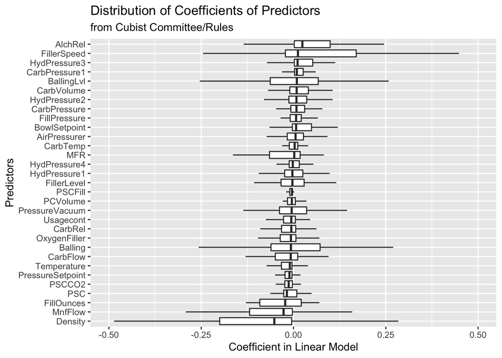

# CART Tree

Using the `rpart` library and its training methods, we consider the best CART based on the `RMSE` metric.

```r
set.seed(10393)

library(rpart)
cartGrid = expand.grid( maxdepth = seq( 1, 20, by = 1 )  )

cartControl <- trainControl(method = "boot",
                            number = 30,
                            selectionFunction = "best")

(rpartTune = train( x = sdata_trainX_pp,
                    y = sdata_train_pp$PH ,
                   method = "rpart2" ,
                   metric = "RMSE" ,
                   tuneGrid = cartGrid ,
                   trControl = cartControl ) )
```

```
## CART
##
## 2055 samples
##   32 predictor
##
## No pre-processing
## Resampling: Bootstrapped (30 reps)
## Summary of sample sizes: 2055, 2055, 2055, 2055, 2055, 2055, ...
## Resampling results across tuning parameters:
##
##   maxdepth  RMSE       Rsquared   MAE
##    1        0.1540934  0.2150028  0.1207013
##    2        0.1485972  0.2697600  0.1163125
##    3        0.1439126  0.3150026  0.1130389
##    4        0.1418976  0.3346403  0.1106321
##    5        0.1408007  0.3455111  0.1095038
##    6        0.1398046  0.3557469  0.1085050
##    7        0.1389994  0.3635874  0.1074293
##    8        0.1381955  0.3717156  0.1065335
##    9        0.1373228  0.3802125  0.1057161
##   10        0.1362384  0.3899605  0.1046780
##   11        0.1353910  0.3979319  0.1038336
##   12        0.1345705  0.4055253  0.1028965
##   13        0.1340562  0.4106769  0.1022712
##   14        0.1335638  0.4154690  0.1017284
##   15        0.1330891  0.4202569  0.1012114
##   16        0.1327996  0.4230057  0.1008957
##   17        0.1327006  0.4239743  0.1008136
##   18        0.1326532  0.4245372  0.1007342
##   19        0.1326119  0.4250877  0.1006977
##   20        0.1326119  0.4250877  0.1006977
##
## RMSE was used to select the optimal model using the smallest value.
## The final value used for the model was maxdepth = 19.
```

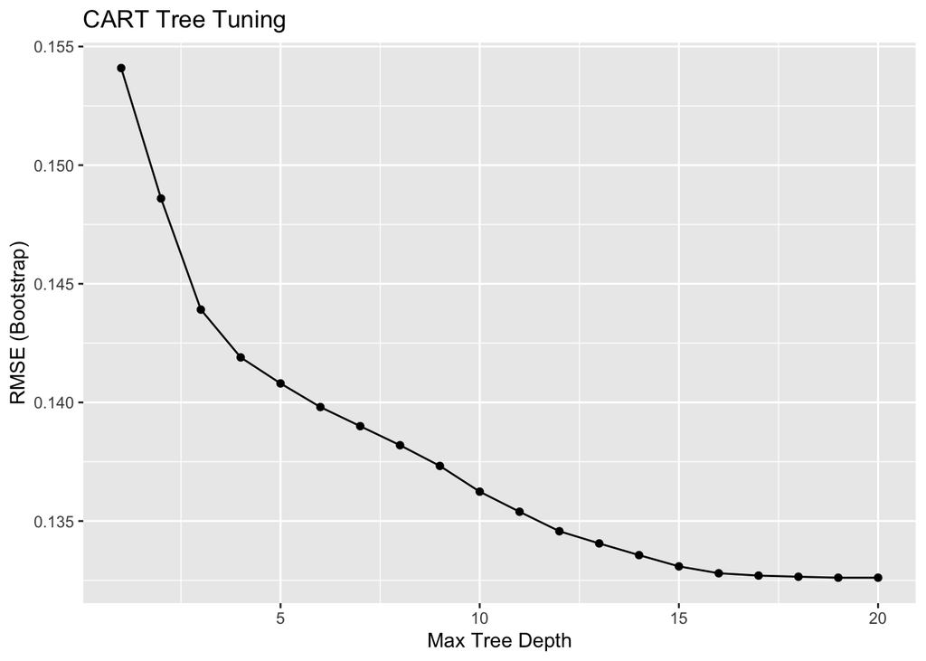

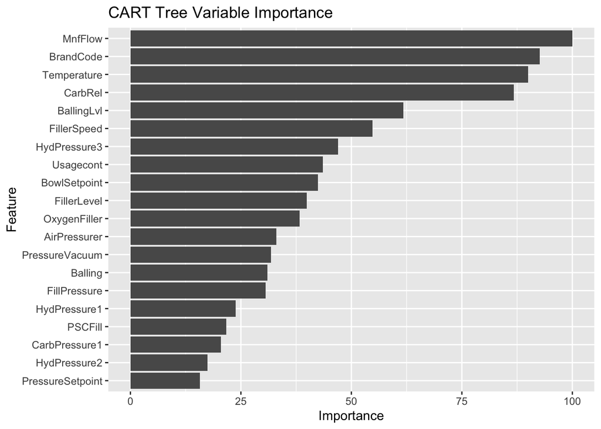

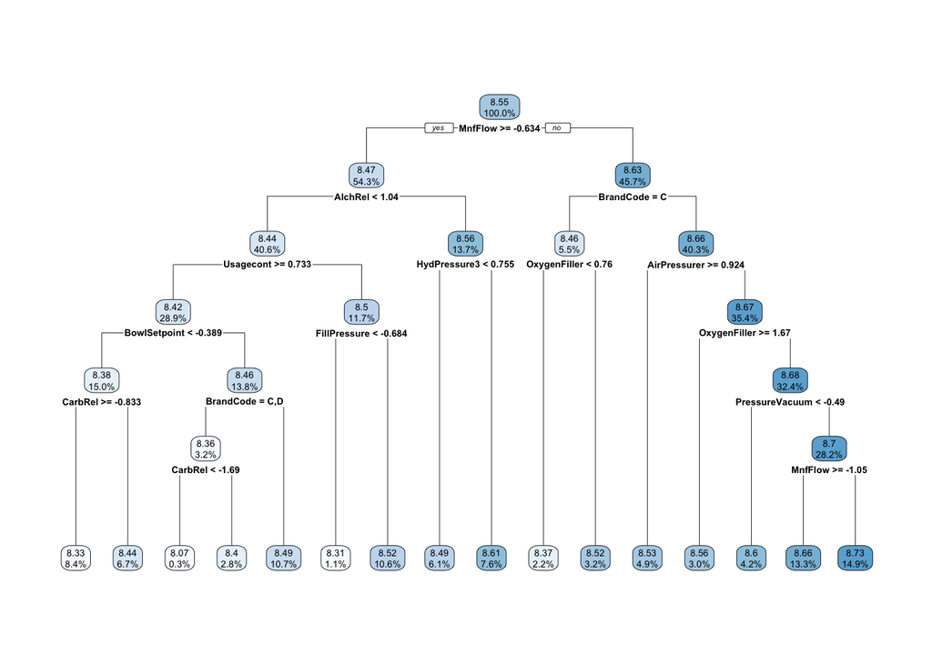

# MARS Model

```
## Selected 22 of 45 terms, and 15 of 35 predictors (nprune=22)
## Termination condition: RSq changed by less than 0.001 at 45 terms
## Importance: MnfFlow, BrandCodeC, AlchRel, AirPressurer, Balling, ...
## Number of terms at each degree of interaction: 1 8 13
## GCV 0.01465292    RSS 28.5643    GRSq 0.5095666    RSq 0.534317
```

```
## Call: earth(x=tbl_df[2055,32], y=c(8.36,8.26,8.9...), keepxy=TRUE, degree=2,
##             nprune=22)
##
##                                                         coefficients
## (Intercept)                                                8.4564109
## h(-0.215889-MnfFlow)                                       0.2412840
## h(HydPressure3- -1.29159)                                  0.0272674
## h(-0.728732-Temperature)                                  -0.0775556
## h(Temperature- -0.728732)                                 -0.0447073
## h(-0.658787-Balling)                                       0.3153913
## h(OxygenFiller- -0.832915)                                -0.0283706
## h(BowlSetpoint- -1.34947)                                  0.0689293
## h(AlchRel-0.640105)                                        0.1158960
## h(1.05286-MnfFlow) * BrandCodeC                           -0.0924403
## h(MnfFlow-1.05286) * BrandCodeC                           -1.1649092
## h(-0.215889-MnfFlow) * h(PressureVacuum-0.386629)         -0.0667719
## h(-0.215889-MnfFlow) * h(0.386629-PressureVacuum)         -0.0950325
## h(-0.215889-MnfFlow) * h(AirPressurer-0.839882)           -0.1271529
## h(MnfFlow- -0.215889) * h(0.640105-AlchRel)               -0.0482870
## h(1.75812-CarbPressure1) * h(BowlSetpoint- -1.34947)      -0.0117283
## h(0.1987-HydPressure1) * h(-0.658787-Balling)             -0.1773508
## h(FillerSpeed-0.21892) * h(Balling- -0.658787)             0.1273751
## h(Temperature-1.27402) * h(BowlSetpoint- -1.34947)         0.0277204
## h(Usagecont-0.0816887) * h(Balling- -0.658787)            -0.0419817
## h(Density-0.482509) * h(BowlSetpoint- -1.34947)           -0.0627989
## h(OxygenFiller- -0.832915) * h(AirPressurer- -0.700718)    0.0261916
##
## Selected 22 of 45 terms, and 15 of 35 predictors (nprune=22)
## Termination condition: RSq changed by less than 0.001 at 45 terms
## Importance: MnfFlow, BrandCodeC, AlchRel, AirPressurer, Balling, ...
## Number of terms at each degree of interaction: 1 8 13
## GCV 0.01465292    RSS 28.5643    GRSq 0.5095666    RSq 0.534317
```

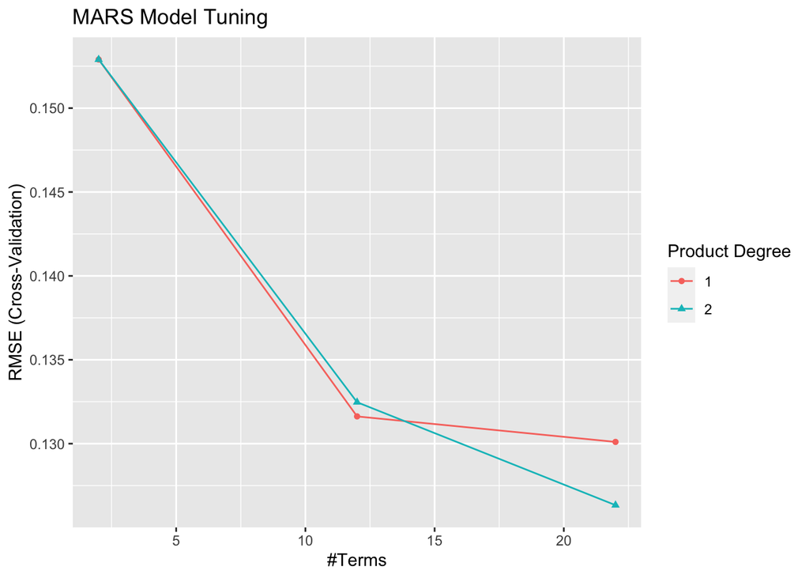

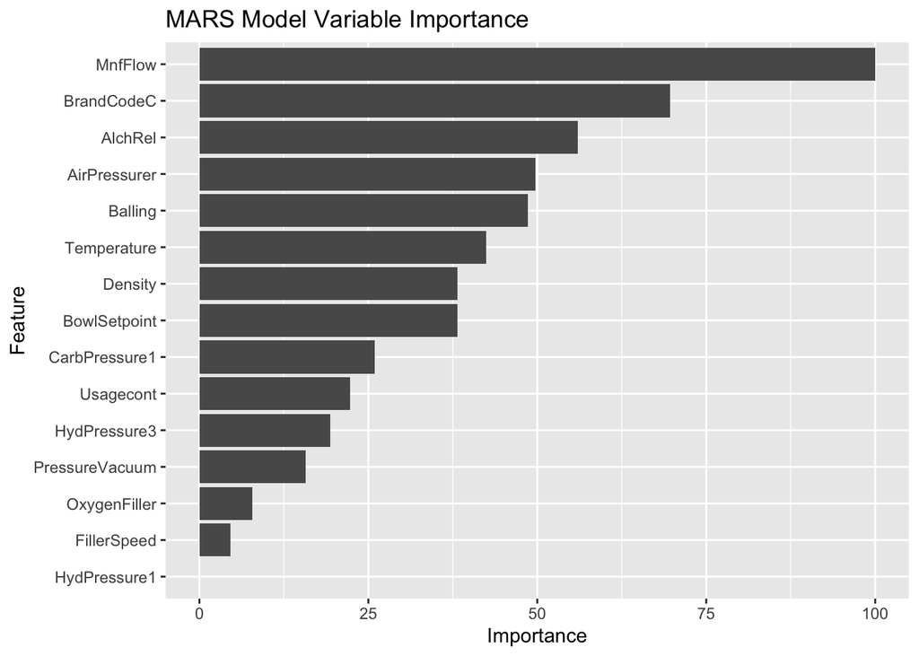

# Linear Regression

We also run a simple OLS regression on PH in terms of the scaled and centered variables. While its predictive performance is weaker than the other models on the training set, the coefficients are much easier to interprete.

```
##
## Call:
## lm(formula = .outcome ~ ., data = dat)
##
## Residuals:
##      Min       1Q   Median       3Q      Max
## -0.51932 -0.07897  0.00917  0.08626  0.44987
##
## Coefficients:
##                   Estimate Std. Error t value Pr(>|t|)
## (Intercept)       8.586130   0.010428 823.364  < 2e-16 ***
## CarbVolume       -0.005488   0.008389  -0.654 0.513047
## FillOunces       -0.004105   0.003163  -1.298 0.194451
## PCVolume         -0.006448   0.003678  -1.753 0.079740 .
## CarbPressure     -0.003088   0.011767  -0.262 0.793033
## CarbTemp          0.008475   0.010712   0.791 0.428936
## PSC              -0.003168   0.003147  -1.007 0.314160
## PSCFill          -0.005762   0.003066  -1.879 0.060361 .
## PSCCO2           -0.006170   0.003020  -2.043 0.041221 *
## MnfFlow          -0.089502   0.006520 -13.728  < 2e-16 ***
## CarbPressure1     0.030465   0.003680   8.278 2.25e-16 ***
## FillPressure      0.005601   0.004501   1.244 0.213528
## HydPressure1      0.004482   0.005177   0.866 0.386658
## HydPressure2     -0.027126   0.009963  -2.723 0.006533 **
## HydPressure3      0.059090   0.010506   5.624 2.12e-08 ***
## HydPressure4      0.001523   0.004624   0.329 0.741982
## FillerLevel      -0.021768   0.008733  -2.493 0.012760 *
## FillerSpeed       0.003863   0.004923   0.785 0.432809
## Temperature      -0.019234   0.003564  -5.397 7.59e-08 ***
## Usagecont        -0.020299   0.003911  -5.191 2.31e-07 ***
## CarbFlow          0.012499   0.004515   2.768 0.005685 **
## Density          -0.018774   0.009023  -2.081 0.037598 *
## MFR               0.002030   0.003898   0.521 0.602651
## Balling          -0.091337   0.014856  -6.148 9.43e-10 ***
## PressureVacuum   -0.016446   0.004588  -3.585 0.000345 ***
## OxygenFiller     -0.015182   0.004217  -3.600 0.000326 ***
## BowlSetpoint      0.053190   0.009135   5.823 6.72e-09 ***
## PressureSetpoint -0.013892   0.004500  -3.087 0.002047 **
## AirPressurer     -0.002649   0.003204  -0.827 0.408420
## AlchRel           0.034578   0.011814   2.927 0.003463 **
## CarbRel           0.005015   0.006593   0.761 0.447003
## BallingLvl        0.097856   0.017857   5.480 4.79e-08 ***
## BrandCodeA       -0.095705   0.025430  -3.764 0.000172 ***
## BrandCodeC       -0.139671   0.010233 -13.649  < 2e-16 ***
## BrandCodeD       -0.043954   0.029625  -1.484 0.138054
## BrandCodeE       -0.057782   0.015435  -3.744 0.000186 ***
## ---
## Signif. codes:  0 '***' 0.001 '**' 0.01 '*' 0.05 '.' 0.1 ' ' 1
##
## Residual standard error: 0.1325 on 2019 degrees of freedom
## Multiple R-squared:  0.4223, Adjusted R-squared:  0.4123
## F-statistic: 42.16 on 35 and 2019 DF,  p-value: < 2.2e-16
```

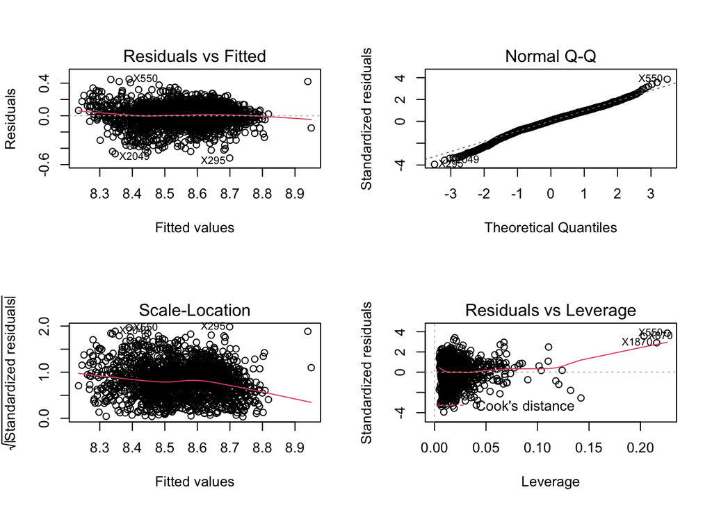

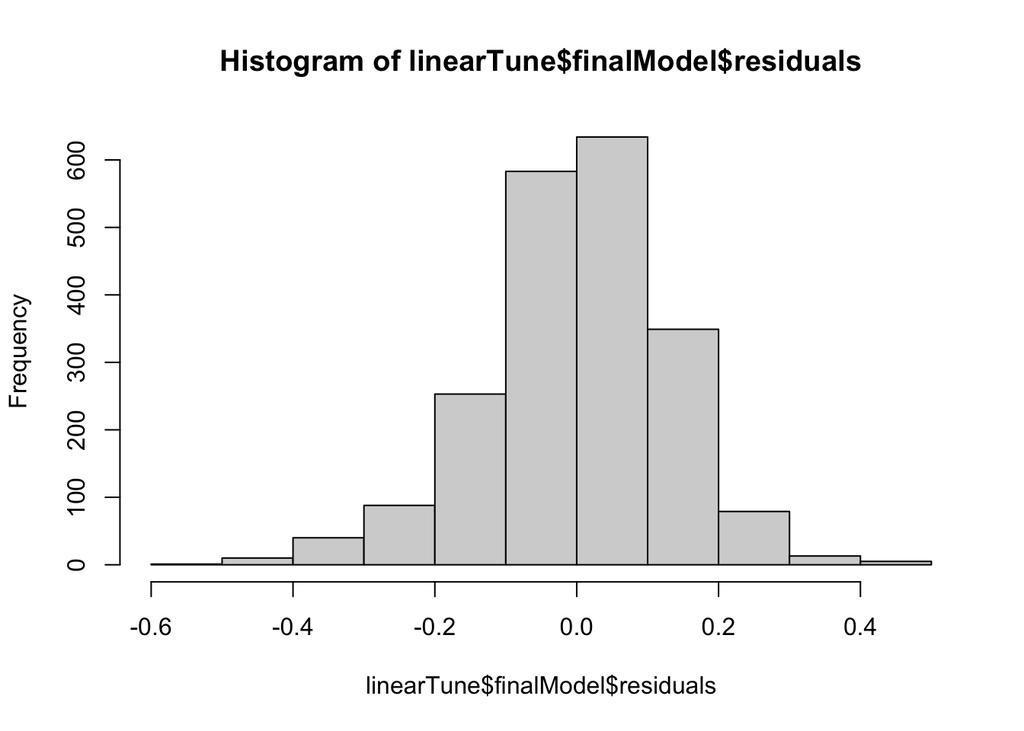

The diagnostic plots of the OLS model suggest that the histogram of residuals is relatively symmetric and looks normal. The QQ plot suggests the model fit does not fully capture the fat tails possibly due to a small number of outliers.

# Model Selection

Based on the above results, we summarize their training and test RMSE and $R^2$ below.

The joint results are tabulated below.

```r
# Make a list of model results collect them from caret for both training and test data and compare them jointly in a kable()

model_list = list( rpartTune , marsTuned , gbmTune, cubistTune, linearTune)

model_stats = data.frame()

for( modelObj in model_list )
{
    if( modelObj$method != 'lm' ){
        pred_data <- as.numeric( predict( modelObj, newdata=sdata_testX_pp ) )[]
    }
    else
    {
        pred_data <- as.numeric( predict( modelObj, newdata=sdata_test_pp ))
    }
    output <- data.frame( modelName = modelObj$method ,
                     trainRMSE = getTrainPerf(modelObj)[1,1] ,
                     trainR2   = getTrainPerf(modelObj)[1,2] ,
                     testRMSE  = caret::RMSE( pred_data,  sdata_test_pp$PH) ,
                     testR2    = caret::R2(   pred_data,  sdata_test_pp$PH)
                     )

    model_stats <- rbind(model_stats, output)
}
```

Model Results Comparison

| modelName | trainRMSE | trainR2 | testRMSE | testR2 |
| --- | --- | --- | --- | --- |
| cubist | 0.096 | 0.693 | 0.091 | 0.718 |
| rpart2 | 0.133 | 0.425 | 0.125 | 0.474 |
| lm | 0.134 | 0.396 | 0.127 | 0.449 |
| gbm | 0.130 | 0.466 | 0.147 | 0.363 |
| earth | 0.126 | 0.475 | 0.155 | 0.255 |

We may also inspect the plot of the predicted versus the observed data for the 4 advanced models. It is clear below that cubist outperforms all others on both the training set in the upper row and also the test data on the lower rows.

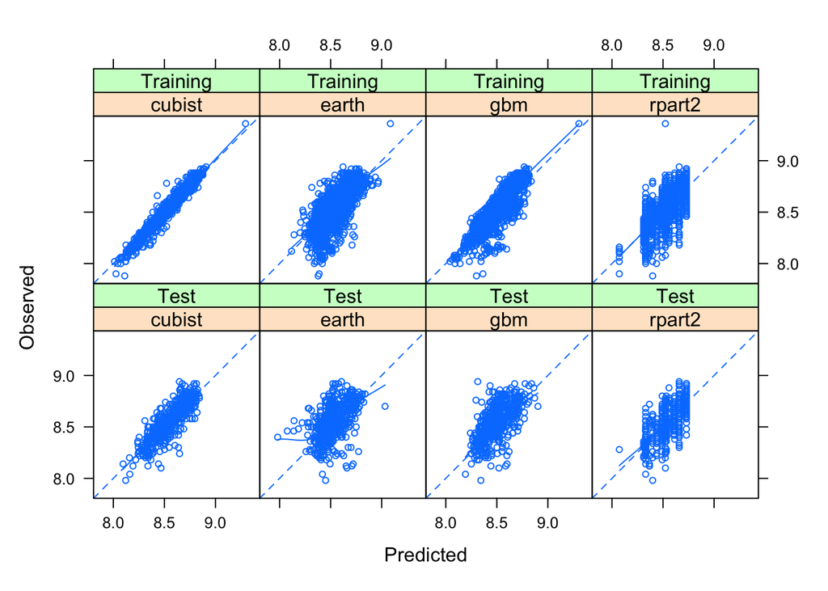

We plot the prediction vs actual for the linear regression model below separately but the results still support cubist as being superior.

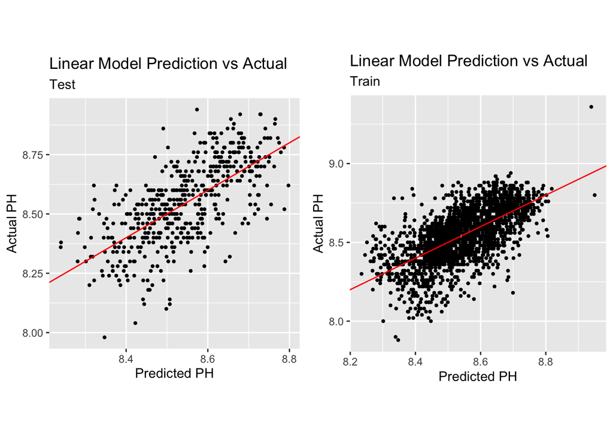

# Discussion

We conclude that the best model is Cubist but the multilinear regression model, MARS and CART models provide useful insight on the main predictors.

- We would recommend the use of the Cubist model for prediction
- However, the OLS (ordinary least squares) linear regression help us to understand the sign and magnitude of the most important variables.
- The MARS model helps to detect non-linearity and predictor interaction in prediction.

The top 5 variables that impact PH are:

`MnfFlow` - this appears negatively related to `PH` level based on OLS, MARS and Cubist median plot. `BallingLvl` is positively related to `PH` level. `PreserveVacuum` is negatively related to `PH.` `AlchRel` is positively related to `PH`. `Balling` is negatively related to `PH`.

Lastly, we observe that Brand is probably not a manufacturing predictor that can be controlled. Mostly likely Brand refers to a recipe for the final product. However, knowing the desired optimal `PH` for each Brand may help us control the most influential variables that control `PH`, thereby providing better quality control. While there are over 30 predictors in the dataset, we recommend looking at the top 10 most influential predictors. Most of the models agree substantially on which predictors to include in the top 10.

# Code

We summarize all the R code used in this project in this appendix for ease of reading.

```r
knitr::opts_chunk$set(echo = FALSE)
suppressPackageStartupMessages(library(knitr) )
suppressPackageStartupMessages( library(tidyverse) )
suppressPackageStartupMessages(library(kableExtra) )
library(cowplot)
library(skimr)

library(RColorBrewer)
library(caret)
library(Cubist)
library(rpart)
suppressPackageStartupMessages(library(gbm) )
library(party)


tuningFull = TRUE

.code-bg {
  background-color: lightgray;
}

sdata_train_pp = read_csv("sdata_train_pp.csv",
                          col_types = cols( .default = "?", id = "i" , BrandCode = "f")) %>%
  as_tibble() %>% remove_rownames()

sdata_test_pp  = read_csv("sdata_test_pp.csv", col_types = cols( .default = "?", id = "i" , BrandCode = "f")) %>%
  as_tibble() %>% remove_rownames()

sdata_trainX_pp  = sdata_train_pp %>% select( -PH, -id )
sdata_testX_pp   = sdata_test_pp %>% select(-PH , -id)


tuningFull = FALSE   # Set to TRUE if running the lengthy tuning process for all models

set.seed( 1027)

gbmControlFull <- trainControl(method = "repeatedcv",
                           number = 10,  # for debug mode, set this to a low number (1)
                           repeats = 10 ,
                           selectionFunction = "best",
                           verboseIter = FALSE)

gbmControlLight <- trainControl(method = "repeatedcv",
                           number = 5,  # for debug mode, set this to a low number (1)
                           repeats = 1 ,
                           selectionFunction = "best",
                           verboseIter = FALSE)

if(tuningFull == TRUE)
{
   gbmControl = gbmControlFull
   gbmTune = expand.grid( n.trees = c( 1000, 2000),
                                                  shrinkage = c( 0.02, 0.05,  0.1 , 0.15 ) ,
                                                  interaction.depth = c(  3, 7) ,
                                                  n.minobsinnode = 4
                                                  )
} else  {
   gbmControl = gbmControlLight
   gbmTune =  expand.grid( n.trees = c( 2000),
                                                  shrinkage = c( 0.02, 0.05 , 0.1 ) ,
                                                  interaction.depth = c(  3, 7) ,
                                                  n.minobsinnode = 4
                                                  )
}

(gbmTune = caret::train( x = sdata_trainX_pp,
                          y = sdata_train_pp$PH ,
                          method = "gbm",
                          tuneGrid =  gbmTune ,
                          verbose = FALSE,
                          metric = "RMSE" ,
                          trControl = gbmControl ) )



ggplot(gbmTune) + labs(title = "Gradient Boosted Trees - Tuning")

ggplot(varImp(gbmTune, numTrees = gbmTune$finalModel$n.trees) ) + labs(title = "Gradient Boosted Trees - Variance Importance")

set.seed( 1027)

cubistControlFull <- trainControl(method = "cv" ,  selectionFunction = "best")
tuneGridFull  <- expand.grid( committees = c( 10, 50, 100 ) ,
                              neighbors = c( 0, 1, 5, 9 )
                                                  )

cubistControlLight <- trainControl(method = "cv" ,  selectionFunction = "best")
tuneGridLight <- expand.grid( committees = c( 10, 20 ) ,
                              neighbors = c( 0, 5 )  )

if(tuningFull == TRUE)
{
   cubistControl = cubistControlFull
   cubistGrid = tuneGridFull
} else  {
   cubistControl = cubistControlLight
   cubistGrid = tuneGridLight
}



(cubistTune = caret::train( x = sdata_trainX_pp,
                          y = sdata_train_pp$PH ,
                          method = "cubist",
                          tuneGrid = cubistGrid ,
                          verbose = FALSE,
                          metric = "RMSE" ,
                          trControl = cubistControl ) )

ggplot(cubistTune) + labs(title="Cubist Model Tuning")

ggplot(varImp(cubistTune), top = 20) + labs(title = "Cubist Model Variable Importance")
cubistTune$finalModel

cubistTune$finalModel$usage %>% arrange( desc(Model+ Conditions)) %>%
  kable(caption = "Cubist Predictor Usage") %>% kable_styling(bootstrap_options = c("hover", "striped"), position = "left")

dotplot( cubistTune$finalModel, what = "splits" )

dotplot( cubistTune$finalModel,
         what = "coefs",
         between = list(x = 0.2, y = 0.5) ,
         scales = list(x = list(relation = "free"),
                       y = list(cex = 0.25)  ) )

cubistTune$finalModel$coefficients %>%
  rownames_to_column(var="id") %>%
  select(-committee, -rule) %>%
  pivot_longer(!id, names_to = "predictor", values_to = "coef" ) %>%
  filter( !is.na(coef)) %>%
  filter( predictor != '(Intercept)' )  %>%
  filter(abs(coef) < 20 ) -> coef_piv

coef_piv %>%
  ggplot() +
  geom_boxplot(
    aes(x=reorder(predictor, coef, FUN = median, na.rm = TRUE ),  # order the boxplots by median
        y = coef ), outlier.shape = NA ) +  # strip out the outliers
  coord_flip(ylim=c(-.5,.5)) +
  labs(title = "Distribution of Coefficients of Predictors",
       subtitle = "from Cubist Committee/Rules",
       x = "Predictors" ,
       y = "Coefficient in Linear Model"
       )

set.seed(10393)

library(rpart)
cartGrid = expand.grid( maxdepth = seq( 1, 20, by = 1 )  )

cartControl <- trainControl(method = "boot",
                            number = 30,
                            selectionFunction = "best")

(rpartTune = train( x = sdata_trainX_pp,
                    y = sdata_train_pp$PH ,
                   method = "rpart2" ,
                   metric = "RMSE" ,
                   tuneGrid = cartGrid ,
                   trControl = cartControl ) )


ggplot(rpartTune) + labs(title="CART Tree Tuning")
ggplot(varImp( rpartTune), top = 20 ) + labs(title = "CART Tree Variable Importance")

library(rpart.plot)
library(partykit)

rpart.plot(rpartTune$finalModel, digits = 3)

if( tuningFull == TRUE )
{
    marsGrid = expand.grid( .degree = 1:2, .nprune = seq(2,27, by=5) )
    marsControl = trainControl(method = "cv",
                     number = 10,

                     selectionFunction = "best",
                     verboseIter = FALSE)
} else {
    marsGrid = expand.grid( .degree = 1:2, .nprune = seq(2,25, by = 10 ) )

    marsControl = trainControl(method = "cv",
                     number = 10,

                     selectionFunction = "best",
                     verboseIter = TRUE)
}


set.seed(1000)

marsTuned = caret::train(x = sdata_trainX_pp ,
                         y = sdata_train_pp$PH,
                         method = "earth" ,
                         metric = "RMSE" ,
                         tuneGrid = marsGrid ,
                         trControl = marsControl )
marsTuned$finalModel

summary(marsTuned)
ggplot(marsTuned) + labs(title="MARS Model Tuning" )

ggplot( varImp(marsTuned), 20 ) + labs(title = "MARS Model Variable Importance")


set.seed(123)

train.control <- trainControl( method = "cv", number = 5)

linearTune = train( PH ~ . -id, data = sdata_train_pp,
                  method = "lm",
                  tuneGrid = data.frame(intercept = TRUE),
                  trControl = train.control)

summary(linearTune$finalModel)

par(mfrow=c(2,2))
plot(linearTune$finalModel)
hist(linearTune$finalModel$residuals)


# Make a list of model results collect them from caret for both training and test data and compare them jointly in a kable()

model_list = list( rpartTune , marsTuned , gbmTune, cubistTune, linearTune)

model_stats = data.frame()

for( modelObj in model_list )
{
    if( modelObj$method != 'lm' ){
        pred_data <- as.numeric( predict( modelObj, newdata=sdata_testX_pp ) )[]
    }
    else
    {
        pred_data <- as.numeric( predict( modelObj, newdata=sdata_test_pp ))
    }
    output <- data.frame( modelName = modelObj$method ,
                     trainRMSE = getTrainPerf(modelObj)[1,1] ,
                     trainR2   = getTrainPerf(modelObj)[1,2] ,
                     testRMSE  = caret::RMSE( pred_data,  sdata_test_pp$PH) ,
                     testR2    = caret::R2(   pred_data,  sdata_test_pp$PH)
                     )

    model_stats <- rbind(model_stats, output)
}



model_stats %>% as_tibble() %>%
  arrange( testRMSE) %>%
  kable( digits = 3, caption = "Model Results Comparison") %>%
  kable_styling(bootstrap_options = c("hover", "striped"), position = "left")

predVals = extractPrediction(list(marsTuned, rpartTune, cubistTune, gbmTune), testX = sdata_testX_pp , testY = sdata_test_pp$PH )

# Plot using Caret built-in reporting.
# --------------------------------------
plotObsVsPred(predVals)

pred_lm =  predict(  linearTune, newdata = sdata_test_pp  )

ggplot() + geom_point( aes(x = pred_lm, y = sdata_test_pp$PH), size = 0.8) +
  geom_abline(slope = 1, intercept = 0, col = "red") +
  theme(aspect.ratio = 1) + labs(title="Linear Model Prediction vs Actual", subtitle = "Test",
                                 x = "Predicted PH", y = "Actual PH") -> p1

pred_lm_train = linearTune$finalModel$fitted.values


ggplot() + geom_point( aes(x = pred_lm_train, y = sdata_train_pp$PH), size = 0.8) +
  geom_abline(slope = 1, intercept = 0, col = "red") +
  theme(aspect.ratio = 1) + labs(title="Linear Model Prediction vs Actual", subtitle = "Train",
                                 x = "Predicted PH", y = "Actual PH") -> p2


plot_grid(p1, p2, ncol = 2)
```